# Homework1_Sabrina_Zhang

Author

Sabrina Zhang

## Step 1 read data and EDA

```r
# read data files
pm_2022 <- read.csv("D:/USC-MPH2025/PM566/PM566/pm2.5_Cal_2022.csv")
pm_2002 <- read.csv("D:/USC-MPH2025/PM566/PM566/pm2.5_Cal_2002.csv")

# EDA check the data
dim(pm_2022)
```

```
[1] 59918    22
```

```r
dim(pm_2002)
```

```
[1] 15976    22
```

```r
# head and tail rows
head(pm_2022)
```

```
        Date Source  Site.ID POC Daily.Mean.PM2.5.Concentration    Units
1 01/01/2022    AQS 60010007   3                           12.7 ug/m3 LC
2 01/02/2022    AQS 60010007   3                           13.9 ug/m3 LC
3 01/03/2022    AQS 60010007   3                            7.1 ug/m3 LC
4 01/04/2022    AQS 60010007   3                            3.7 ug/m3 LC
5 01/05/2022    AQS 60010007   3                            4.2 ug/m3 LC
6 01/06/2022    AQS 60010007   3                            3.8 ug/m3 LC
  Daily.AQI.Value Local.Site.Name Daily.Obs.Count Percent.Complete
1              58       Livermore               1              100
2              60       Livermore               1              100
3              39       Livermore               1              100
4              21       Livermore               1              100
5              23       Livermore               1              100
6              21       Livermore               1              100
  AQS.Parameter.Code AQS.Parameter.Description Method.Code
```

[output cut: 27 more lines]

```r
tail(pm_2022)
```

```
            Date Source  Site.ID POC Daily.Mean.PM2.5.Concentration    Units
59913 12/01/2022    AQS 61131003   1                            3.4 ug/m3 LC
59914 12/07/2022    AQS 61131003   1                            3.8 ug/m3 LC
59915 12/13/2022    AQS 61131003   1                            6.0 ug/m3 LC
59916 12/19/2022    AQS 61131003   1                           34.8 ug/m3 LC
59917 12/25/2022    AQS 61131003   1                           23.2 ug/m3 LC
59918 12/31/2022    AQS 61131003   1                            1.0 ug/m3 LC
      Daily.AQI.Value      Local.Site.Name Daily.Obs.Count Percent.Complete
59913              19 Woodland-Gibson Road               1              100
59914              21 Woodland-Gibson Road               1              100
59915              33 Woodland-Gibson Road               1              100
59916              99 Woodland-Gibson Road               1              100
59917              77 Woodland-Gibson Road               1              100
59918               6 Woodland-Gibson Road               1              100
      AQS.Parameter.Code AQS.Parameter.Description Method.Code
```

[output cut: 27 more lines]

```r
head(pm_2002)
```

```
        Date Source  Site.ID POC Daily.Mean.PM2.5.Concentration    Units
1 01/05/2002    AQS 60010007   1                           25.1 ug/m3 LC
2 01/06/2002    AQS 60010007   1                           31.6 ug/m3 LC
3 01/08/2002    AQS 60010007   1                           21.4 ug/m3 LC
4 01/11/2002    AQS 60010007   1                           25.9 ug/m3 LC
5 01/14/2002    AQS 60010007   1                           34.5 ug/m3 LC
6 01/17/2002    AQS 60010007   1                           41.0 ug/m3 LC
  Daily.AQI.Value Local.Site.Name Daily.Obs.Count Percent.Complete
1              81       Livermore               1              100
2              93       Livermore               1              100
3              74       Livermore               1              100
4              82       Livermore               1              100
5              98       Livermore               1              100
6             115       Livermore               1              100
  AQS.Parameter.Code AQS.Parameter.Description Method.Code
```

[output cut: 27 more lines]

```r
tail(pm_2002)
```

```
            Date Source  Site.ID POC Daily.Mean.PM2.5.Concentration    Units
15971 12/10/2002    AQS 61131003   1                             15 ug/m3 LC
15972 12/13/2002    AQS 61131003   1                             15 ug/m3 LC
15973 12/22/2002    AQS 61131003   1                              1 ug/m3 LC
15974 12/25/2002    AQS 61131003   1                             23 ug/m3 LC
15975 12/28/2002    AQS 61131003   1                              5 ug/m3 LC
15976 12/31/2002    AQS 61131003   1                              6 ug/m3 LC
      Daily.AQI.Value      Local.Site.Name Daily.Obs.Count Percent.Complete
15971              62 Woodland-Gibson Road               1              100
15972              62 Woodland-Gibson Road               1              100
15973               6 Woodland-Gibson Road               1              100
15974              77 Woodland-Gibson Road               1              100
15975              28 Woodland-Gibson Road               1              100
15976              33 Woodland-Gibson Road               1              100
      AQS.Parameter.Code AQS.Parameter.Description Method.Code
```

[output cut: 27 more lines]

```r
# check variable and data type
names(pm_2022)
```

```
 [1] "Date"                           "Source"
 [3] "Site.ID"                        "POC"
 [5] "Daily.Mean.PM2.5.Concentration" "Units"
 [7] "Daily.AQI.Value"                "Local.Site.Name"
 [9] "Daily.Obs.Count"                "Percent.Complete"
[11] "AQS.Parameter.Code"             "AQS.Parameter.Description"
[13] "Method.Code"                    "Method.Description"
[15] "CBSA.Code"                      "CBSA.Name"
[17] "State.FIPS.Code"                "State"
[19] "County.FIPS.Code"               "County"
[21] "Site.Latitude"                  "Site.Longitude"
```

```r
str(pm_2022)
```

```
'data.frame':   59918 obs. of  22 variables:
 $ Date                          : chr  "01/01/2022" "01/02/2022" "01/03/2022" "01/04/2022" ...
 $ Source                        : chr  "AQS" "AQS" "AQS" "AQS" ...
 $ Site.ID                       : int  60010007 60010007 60010007 60010007 60010007 60010007 60010007 60010007 60010007 60010007 ...
 $ POC                           : int  3 3 3 3 3 3 3 3 3 3 ...
 $ Daily.Mean.PM2.5.Concentration: num  12.7 13.9 7.1 3.7 4.2 3.8 2.3 6.9 13.6 11.2 ...
 $ Units                         : chr  "ug/m3 LC" "ug/m3 LC" "ug/m3 LC" "ug/m3 LC" ...
 $ Daily.AQI.Value               : int  58 60 39 21 23 21 13 38 59 55 ...
 $ Local.Site.Name               : chr  "Livermore" "Livermore" "Livermore" "Livermore" ...
 $ Daily.Obs.Count               : int  1 1 1 1 1 1 1 1 1 1 ...
 $ Percent.Complete              : num  100 100 100 100 100 100 100 100 100 100 ...
 $ AQS.Parameter.Code            : int  88101 88101 88101 88101 88101 88101 88101 88101 88101 88101 ...
 $ AQS.Parameter.Description     : chr  "PM2.5 - Local Conditions" "PM2.5 - Local Conditions" "PM2.5 - Local Conditions" "PM2.5 - Local Conditions" ...
 $ Method.Code                   : int  170 170 170 170 170 170 170 170 170 170 ...
 $ Method.Description            : chr  "Met One BAM-1020 Mass Monitor w/VSCC" "Met One BAM-1020 Mass Monitor w/VSCC" "Met One BAM-1020 Mass Monitor w/VSCC" "Met One BAM-1020 Mass Monitor w/VSCC" ...
 $ CBSA.Code                     : int  41860 41860 41860 41860 41860 41860 41860 41860 41860 41860 ...
 $ CBSA.Name                     : chr  "San Francisco-Oakland-Hayward, CA" "San Francisco-Oakland-Hayward, CA" "San Francisco-Oakland-Hayward, CA" "San Francisco-Oakland-Hayward, CA" ...
 $ State.FIPS.Code               : int  6 6 6 6 6 6 6 6 6 6 ...
 $ State                         : chr  "California" "California" "California" "California" ...
 $ County.FIPS.Code              : int  1 1 1 1 1 1 1 1 1 1 ...
 $ County                        : chr  "Alameda" "Alameda" "Alameda" "Alameda" ...
 $ Site.Latitude                 : num  37.7 37.7 37.7 37.7 37.7 ...
 $ Site.Longitude                : num  -122 -122 -122 -122 -122 ...
```

```r
str(pm_2002)
```

```
'data.frame':   15976 obs. of  22 variables:
 $ Date                          : chr  "01/05/2002" "01/06/2002" "01/08/2002" "01/11/2002" ...
 $ Source                        : chr  "AQS" "AQS" "AQS" "AQS" ...
 $ Site.ID                       : int  60010007 60010007 60010007 60010007 60010007 60010007 60010007 60010007 60010007 60010007 ...
 $ POC                           : int  1 1 1 1 1 1 1 1 1 1 ...
 $ Daily.Mean.PM2.5.Concentration: num  25.1 31.6 21.4 25.9 34.5 41 29.3 15 18.8 37.9 ...
 $ Units                         : chr  "ug/m3 LC" "ug/m3 LC" "ug/m3 LC" "ug/m3 LC" ...
 $ Daily.AQI.Value               : int  81 93 74 82 98 115 89 62 69 107 ...
 $ Local.Site.Name               : chr  "Livermore" "Livermore" "Livermore" "Livermore" ...
 $ Daily.Obs.Count               : int  1 1 1 1 1 1 1 1 1 1 ...
 $ Percent.Complete              : num  100 100 100 100 100 100 100 100 100 100 ...
 $ AQS.Parameter.Code            : int  88101 88101 88101 88101 88101 88101 88101 88101 88101 88101 ...
 $ AQS.Parameter.Description     : chr  "PM2.5 - Local Conditions" "PM2.5 - Local Conditions" "PM2.5 - Local Conditions" "PM2.5 - Local Conditions" ...
 $ Method.Code                   : int  120 120 120 120 120 120 120 120 120 120 ...
 $ Method.Description            : chr  "Andersen RAAS2.5-300 PM2.5 SEQ w/WINS" "Andersen RAAS2.5-300 PM2.5 SEQ w/WINS" "Andersen RAAS2.5-300 PM2.5 SEQ w/WINS" "Andersen RAAS2.5-300 PM2.5 SEQ w/WINS" ...
 $ CBSA.Code                     : int  41860 41860 41860 41860 41860 41860 41860 41860 41860 41860 ...
 $ CBSA.Name                     : chr  "San Francisco-Oakland-Hayward, CA" "San Francisco-Oakland-Hayward, CA" "San Francisco-Oakland-Hayward, CA" "San Francisco-Oakland-Hayward, CA" ...
 $ State.FIPS.Code               : int  6 6 6 6 6 6 6 6 6 6 ...
 $ State                         : chr  "California" "California" "California" "California" ...
 $ County.FIPS.Code              : int  1 1 1 1 1 1 1 1 1 1 ...
 $ County                        : chr  "Alameda" "Alameda" "Alameda" "Alameda" ...
 $ Site.Latitude                 : num  37.7 37.7 37.7 37.7 37.7 ...
 $ Site.Longitude                : num  -122 -122 -122 -122 -122 ...
```

```r
# Check key variable descriptive distribution
summary(pm_2022$Daily.Mean.PM2.5.Concentration)
```

```
   Min. 1st Qu.  Median    Mean 3rd Qu.    Max.
 -6.700   4.100   6.800   8.414  10.700 302.500
```

```r
summary(pm_2002$Daily.Mean.PM2.5.Concentration)
```

```
   Min. 1st Qu.  Median    Mean 3rd Qu.    Max.
   0.00    7.00   12.00   16.12   20.50  104.30
```

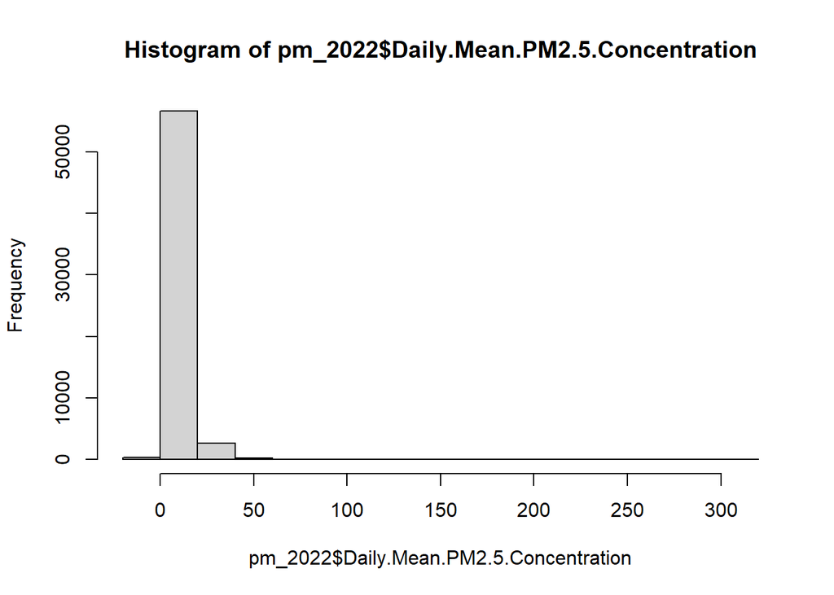

```r
# Plot histogram
hist(pm_2022$Daily.Mean.PM2.5.Concentration)
```

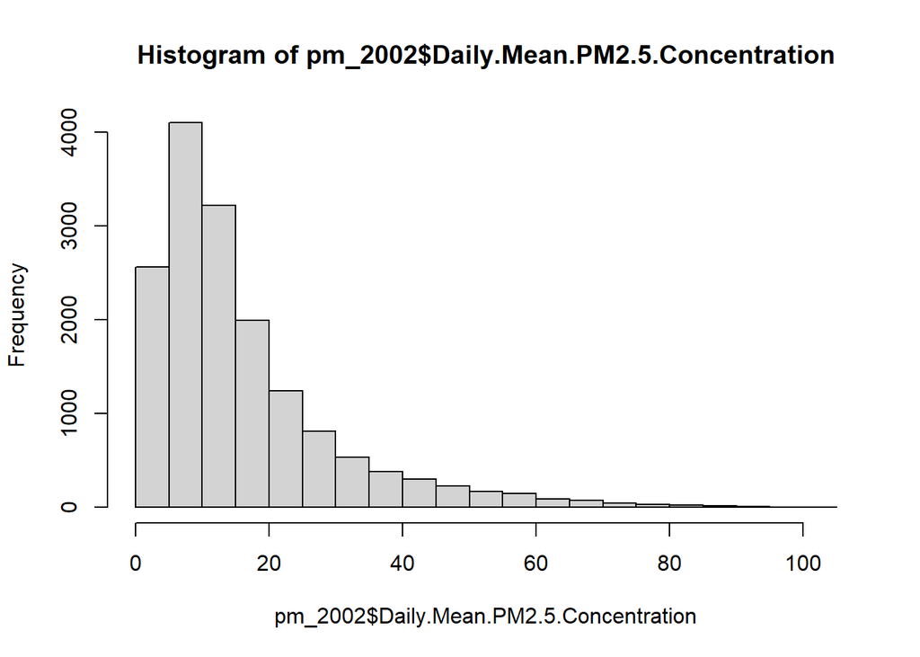

```r
hist(pm_2002$Daily.Mean.PM2.5.Concentration)
```

```r
# Check missings
mean(is.na(pm_2022$Daily.Mean.PM2.5.Concentration))
```

```
[1] 0
```

```r
mean(is.na(pm_2002$Daily.Mean.PM2.5.Concentration))
```

```
[1] 0
```

```r
#number of sites
length(unique(pm_2022$Local.Site.Name))
```

```
[1] 165
```

```r
length(unique(pm_2002$Local.Site.Name))
```

```
[1] 103
```

The California PM2.5 datasets from 2002 and 2022 contain similar structures with 22 variables each, but differ significantly in their PM2.5 measurements. The 2022 dataset has 59,918 observations while 2002 has 15,976 observations,because of more monitoring sites allocated in these 20 years (103 sites in 2002 and 165 sites in 2022).

The PM2.5 concentration variable shows no missing values in either year. The 2002 data shows a higher median PM2.5 concentration (12 ug/m3) compared to 2022 (6.8 ug/m3), suggesting air quality improvements over the 20 year period. The maximum daily mean PM2.5 concentration for 2022 (302.5) significantly higher than 2002(104.3) might indicate more extreme pollution days because of pollution events such as mountain fires.

Dataset in 2022 have some implausible negative values, mindful for further analysis.

## Step 2 Combine data

```r
library(dplyr)
# Convert date to 3 variables
pm_2022$Date <- as.Date(pm_2022$Date, format = "%m/%d/%Y")
pm_2002$Date <- as.Date(pm_2002$Date, format = "%m/%d/%Y")

# Combine
pm_combined <- rbind(pm_2022, pm_2002)
pm_combined$year <- format(pm_combined$Date, "%Y")

# Rename variables
names(pm_combined)[names(pm_combined) == "Daily.Mean.PM2.5.Concentration"] <- "PM25"
names(pm_combined)[names(pm_combined) == "Site.Latitude"] <- "lat"
names(pm_combined)[names(pm_combined) == "Site.Longitude"] <- "lon"
names(pm_combined)[names(pm_combined) == "County"] <- "county"
names(pm_combined)[names(pm_combined) == "Local.Site.Name"] <- "site_name"
```

The 2022 and 2002 datasets were combined into a single dataframe with 75,894 total observations. A year variable was added to distinguish between the two time periods. The Date variable was converted from character format to month day year variables. Key variables were renamed for easier reference in subsequent analyses.

Daily.Mean.PM2.5.Concentration as PM25

Site.Latitude as lat

Site.Longitude as lon

County as county

Local.Site.Name as site_name

## Step 3 Create Map

```r
library(leaflet)

# Plot maps for both years
pm_2022_map_data <- pm_combined %>%
  filter(year == 2022) %>%
  select(lat, lon, site_name) %>%
  distinct()

pm_2002_map_data <- pm_combined %>%
  filter(year == 2002) %>%
  select(lat, lon, site_name) %>%
  distinct()

# Plot map
map <- leaflet() %>%
  addProviderTiles('CartoDB.Positron') %>%
  addCircles(
    data = pm_2022_map_data,
    lat = ~lat, lng = ~lon,
    label = ~site_name,
    color = "red",
    opacity = 0.8,
    fillOpacity = 0.5,
    radius = 400,
    popup = "2022"
  ) %>%
  addCircles(
    data = pm_2002_map_data,
    lat = ~lat, lng = ~lon,
    label = ~site_name,
    color = "blue",
    opacity = 0.5,
    fillOpacity = 0.8,
    radius = 400,
    popup = "2002"
  ) %>%
  addLegend('bottomright',
            colors = c('red', 'blue'),
            labels = c('2022', '2002'),
            opacity = 0.7)

map
```

[interactive chart not shown]

The map comparison reveals notable changes in California’s air quality monitoring network between 2002 and 2022. Both years show monitoring sites distributed across the state, with concentrations in urban areas and regions with significant air quality concerns. The 2022 monitoring network (red dots) appears denser than 2002 (blue dots).

The spatial distribution has remained largely consistent geographically, with monitoring sites concentrated in populated areas. The western coastal areas and the interior valleys remain the focus of monitoring efforts in both years.

## Step 4 Check data

```r
# Check missing
missing_2022 <- mean(is.na(pm_combined$PM25[pm_combined$year == 2022]))
missing_2002 <- mean(is.na(pm_combined$PM25[pm_combined$year == 2002]))

# Check implausible
implausible_count_2022 <- sum(pm_combined$PM25 < 0 & pm_combined$year == 2022, na.rm = TRUE)
implausible_count_2002 <- sum(pm_combined$PM25 < 0 & pm_combined$year == 2002, na.rm = TRUE)
data_quality_summary <- pm_combined %>%
  group_by(year) %>%
  summarise(
    total_obs = n(),
    n_missing = sum(is.na(PM25)),
    prop_missing = round(mean(is.na(PM25)), 4),
    n_implausible = sum(PM25 < 0, na.rm = TRUE),
    prop_implausible = round(mean(PM25 < 0, na.rm = TRUE), 4),
    .groups = 'drop'
  )
print(data_quality_summary)
```

```
# A tibble: 2 × 6
  year  total_obs n_missing prop_missing n_implausible prop_implausible
  <chr>     <int>     <int>        <dbl>         <int>            <dbl>
1 2002      15976         0            0             0           0
2 2022      59918         0            0           215           0.0036
```

```r
#Delete Implausible
pm_combined <- pm_combined[pm_combined$PM25 >= 0, ]

# Distribution by year
summary(pm_combined$PM25[pm_combined$year == 2022])
```

```
   Min. 1st Qu.  Median    Mean 3rd Qu.    Max.
  0.000   4.100   6.800   8.447  10.700 302.500
```

```r
summary(pm_combined$PM25[pm_combined$year == 2002])
```

```
   Min. 1st Qu.  Median    Mean 3rd Qu.    Max.
   0.00    7.00   12.00   16.12   20.50  104.30
```

```r
# double check by year
library(dplyr)
temporal_pattern <- pm_combined %>%
  group_by(year) %>%
  summarise(
    n_obs = n(),
    n_missing = sum(is.na(PM25)),
    prop_missing = mean(is.na(PM25))
  )

print(temporal_pattern)
```

```
# A tibble: 2 × 4
  year  n_obs n_missing prop_missing
  <chr> <int>     <int>        <dbl>
1 2002  15976         0            0
2 2022  59703         0            0
```

Both datasets show zero missing values for the PM2.5 concentration variable. However, the 2022 data contains 215 (0.36%) implausible negative PM2.5 values which are physically impossible as particulate matter concentrations cannot be negative. These likely represent measurement errors or instrument issues, and may indicate changes in measurement methodology or instrument sensitivity between the two years. Therefore, all subsequent analyses exclude the 215 negative PM2.5 observations.

## Step 5 Spatial Analysis

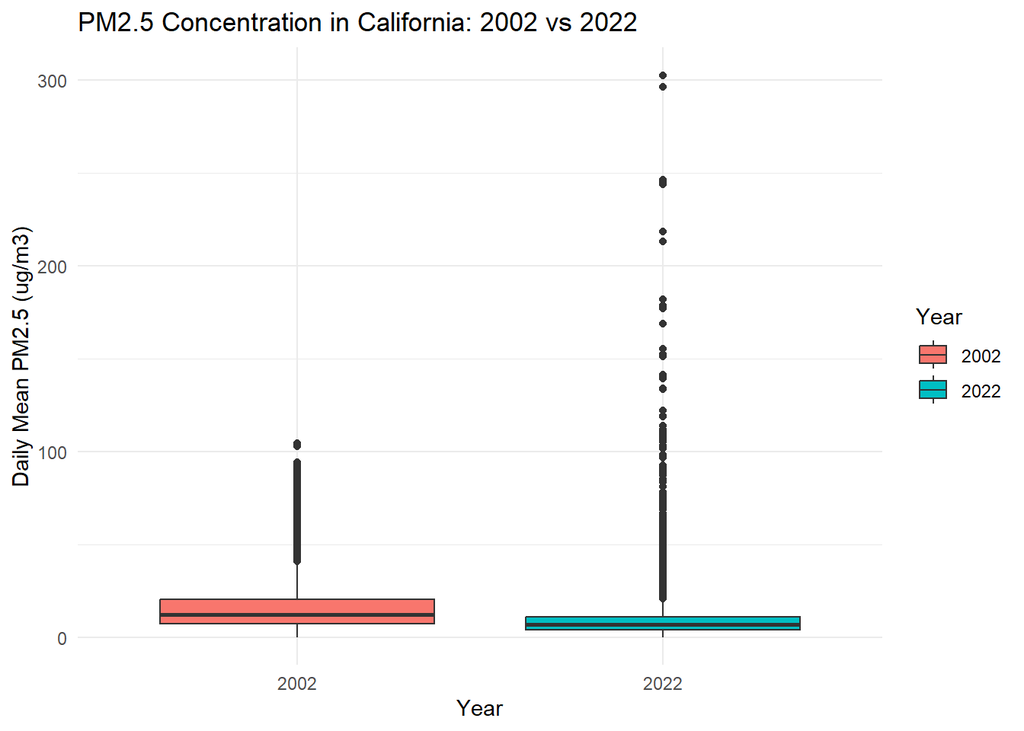

```r
library(ggplot2)

# By state
# Box plot by year
pm_combined %>%
  filter(!is.na(PM25)) %>%
  ggplot(aes(x = factor(year), y = PM25, fill = factor(year))) +
  geom_boxplot() +
  labs(
    title = "PM2.5 Concentration in California: 2002 vs 2022",
    x = "Year",
    y = "Daily Mean PM2.5 (ug/m3)",
    fill = "Year"
  ) +
  theme_minimal()
```

```r
# EDA summary
pm_combined %>%
  filter(!is.na(PM25)) %>%
  group_by(year) %>%
  summarise(
    mean_PM25 = mean(PM25),
    median_PM25 = median(PM25),
    sd_PM25 = sd(PM25),
    min_PM25 = min(PM25),
    max_PM25 = max(PM25)
  )
```

```
# A tibble: 2 × 6
  year  mean_PM25 median_PM25 sd_PM25 min_PM25 max_PM25
  <chr>     <dbl>       <dbl>   <dbl>    <dbl>    <dbl>
1 2002      16.1         12     13.9         0     104.
2 2022       8.45         6.8    7.63        0     302.
```

By state level

The statewide comparison reveals substantial improvement in California’s air quality over the 20-year period. The median PM2.5 concentration decreased from 12.0 ug/m3 in 2002 to 6.8 ug/m3 in 2022.

The distribution of PM2.5 concentrations is right-skewed in both years, with higher pollution events creating occasional spikes. However, 2022 shows a much more concentrated distribution around lower values, reflecting cleaner baseline air quality. The maximum daily concentration increased from 104.3 ug/m3 in 2002 to 302.5 ug/m3 in 2022 , the upper tail for 2022 longer than 2002 , suggesting more extreme high PM2.5 concentrations needing more investigations.

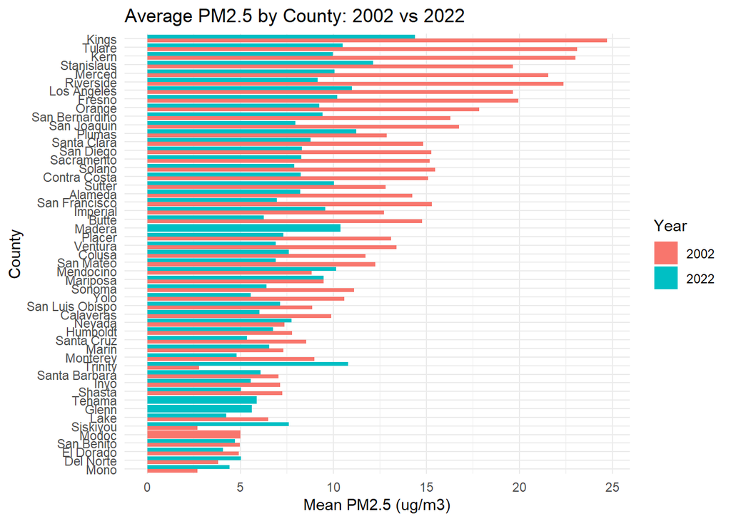

```r
# By county
# Mean
county_avg <- pm_combined %>%
  filter(!is.na(PM25), !is.na(county)) %>%
  group_by(county, year) %>%
  summarise(mean_PM25 = mean(PM25, na.rm = TRUE), .groups = 'drop')

# Visualize mean
county_avg %>%
  ggplot(aes(x = reorder(county, mean_PM25), y = mean_PM25, fill = factor(year))) +
  geom_bar(stat = "identity", position = "dodge") +
  coord_flip() +
  labs(
    title = "Average PM2.5 by County: 2002 vs 2022",
    x = "County",
    y = "Mean PM2.5 (ug/m3)",
    fill = "Year"
  ) +
  theme_minimal()
```

```r
# Compare by counties in both 2002 and 2022
county_2002 <- pm_combined %>%
  filter(year == 2002, !is.na(PM25), !is.na(county)) %>%
  group_by(county) %>%
  summarise(mean_2002 = round(mean(PM25), 2), .groups = 'drop')

county_2022 <- pm_combined %>%
  filter(year == 2022, !is.na(PM25), !is.na(county)) %>%
  group_by(county) %>%
  summarise(mean_2022 = round(mean(PM25), 2), .groups = 'drop')

county_comparison <- merge(
  x = county_2002,
  y = county_2022,
  by = "county",
  all.x = TRUE,
  all.y = FALSE
) %>%
  mutate(
    difference = round(mean_2022 - mean_2002, 2),
    pct_reduction = round((mean_2002 - mean_2022) / mean_2002 * 100, 1)
  ) %>%
  arrange(desc(pct_reduction))

print(county_comparison)
```

```
            county mean_2002 mean_2022 difference pct_reduction
1        Riverside     22.37      9.16     -13.21          59.1
2            Butte     14.76      6.26      -8.50          57.6
3             Kern     23.00      9.96     -13.04          56.7
4    San Francisco     15.31      6.97      -8.34          54.5
5           Tulare     23.10     10.51     -12.59          54.5
6           Merced     21.54     10.06     -11.48          53.3
7      San Joaquin     16.76      7.97      -8.79          52.4
8           Solano     15.48      7.89      -7.59          49.0
9           Fresno     19.93     10.20      -9.73          48.8
10         Ventura     13.40      6.89      -6.51          48.6
11          Orange     17.83      9.25      -8.58          48.1
12            Yolo     10.58      5.55      -5.03          47.5
13        Monterey      8.97      4.81      -4.16          46.4
14       San Diego     15.27      8.30      -6.97          45.6
```

[output cut: 34 more lines]

By county level

The persistent variation between counties indicates that while statewide progress is evident, some regions continue to face air quality challenges relative to others.

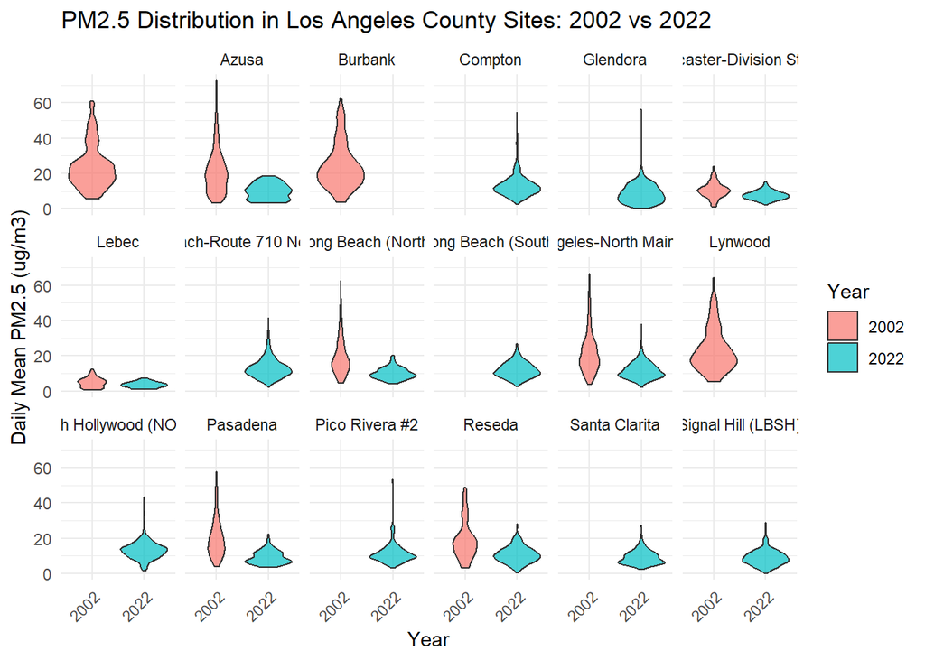

```r
# LA County level
# Filter only LA
la_data <- pm_combined %>%
  filter(county == "Los Angeles", !is.na(PM25))

# PM2.5 Level detected by each site in LA
la_data %>%
  filter(!is.na(site_name)) %>%
  ggplot(aes(x = factor(year), y = PM25, fill = factor(year))) +
  geom_violin(alpha = 0.7) +
  facet_wrap(~ site_name, nrow = 3) +
  labs(
    title = "PM2.5 Distribution in Los Angeles County Sites: 2002 vs 2022",
    x = "Year",
    y = "Daily Mean PM2.5 (ug/m3)",
    fill = "Year"
  ) +
  theme_minimal() +
  theme(axis.text.x = element_text(angle = 45, hjust = 1))
```

```r
# LA EDA summary
la_data %>%
  group_by(year, site_name) %>%
  summarise(
    mean_PM25 = mean(PM25, na.rm = TRUE),
    median_PM25 = median(PM25, na.rm = TRUE),
    n_obs = n()
  )
```

```
`summarise()` has regrouped the output.
ℹ Summaries were computed grouped by year and site_name.
ℹ Output is grouped by year.
ℹ Use `summarise(.groups = "drop_last")` to silence this message.
ℹ Use `summarise(.by = c(year, site_name))` for per-operation grouping
  (`?dplyr::dplyr_by`) instead.
```

```
# A tibble: 25 × 5
# Groups:   year [2]
   year  site_name                       mean_PM25 median_PM25 n_obs
   <chr> <chr>                               <dbl>       <dbl> <int>
 1 2002  ""                                  23.9         21.4   118
 2 2002  "Azusa"                             20.8         18.7   339
 3 2002  "Burbank"                           24.0         21.6   122
 4 2002  "Lancaster-Division Street"         10.4         10     107
 5 2002  "Lebec"                              4.82         4.8   109
 6 2002  "Long Beach (North)"                19.5         16.8   356
 7 2002  "Los Angeles-North Main Street"     22.0         19.3   365
 8 2002  "Lynwood"                           23.3         19.8   122
 9 2002  "Pasadena"                          20.3         17.8   121
10 2002  "Reseda"                            18.9         17.0   120
# ℹ 15 more rows
```

```r
# Compare by sites in both 2002 and 2022
common_sites <- la_data %>%
  group_by(site_name) %>%
  summarise(n_years = n_distinct(year), .groups = 'drop') %>%
  filter(n_years == 2) %>%
  pull(site_name)
la_common <- la_data %>% filter(site_name %in% common_sites, !is.na(PM25))
la_common %>%
  group_by(year) %>%
  summarise(
    mean_PM25 = round(mean(PM25), 2),
    median_PM25 = round(median(PM25), 2),
    sd_PM25 = round(sd(PM25), 2),
    .groups = 'drop'
  )
```

```
# A tibble: 2 × 4
  year  mean_PM25 median_PM25 sd_PM25
  <chr>     <dbl>       <dbl>   <dbl>
1 2002       18.7        16.5    11.6
2 2022       10.2         9.5     4.5
```

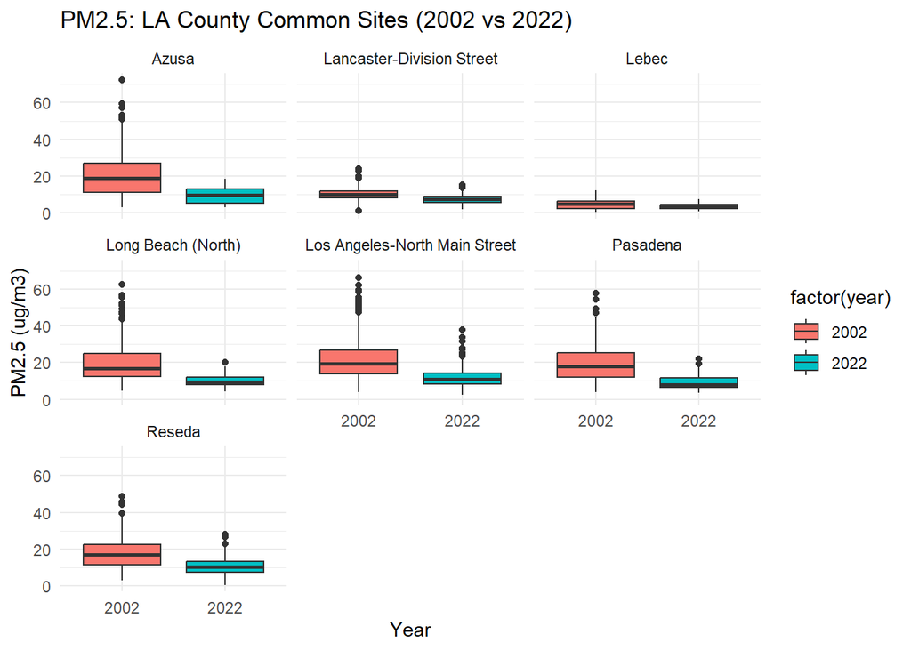

```r
la_common %>%
  ggplot(aes(x = factor(year), y = PM25, fill = factor(year))) +
  geom_boxplot() +
  facet_wrap(~site_name) +
  labs(title = "PM2.5: LA County Common Sites (2002 vs 2022)",
       x = "Year", y = "PM2.5 (ug/m3)") +
  theme_minimal()
```

```r
#comparing between 2 years in sites
summary_2002 <- la_common %>%
  filter(year == 2002) %>%
  group_by(site_name) %>%
  summarise(mean_2002 = round(mean(PM25), 2), .groups = 'drop')

summary_2022 <- la_common %>%
  filter(year == 2022) %>%
  group_by(site_name) %>%
  summarise(mean_2022 = round(mean(PM25), 2), .groups = 'drop')

comparison <- merge(
  x = summary_2002,
  y = summary_2022,
  by = "site_name",
  all.x = TRUE,
  all.y = FALSE
) %>%
  mutate(
    difference = round(mean_2022 - mean_2002, 2),
    pct_reduction = round((mean_2002 - mean_2022) / mean_2002 * 100, 1)
  ) %>%
  arrange(desc(pct_reduction))

print(comparison)
```

```
                      site_name mean_2002 mean_2022 difference pct_reduction
1                      Pasadena     20.29      9.09     -11.20          55.2
2                         Azusa     20.76      9.72     -11.04          53.2
3            Long Beach (North)     19.47      9.92      -9.55          49.0
4 Los Angeles-North Main Street     21.97     11.58     -10.39          47.3
5                        Reseda     18.85     10.72      -8.13          43.1
6     Lancaster-Division Street     10.38      7.52      -2.86          27.6
7                         Lebec      4.82      3.50      -1.32          27.4
```

By city level